# Analysis of Sonya translatome data

This document details the analysis of proteomics data acquired to look at the translatome of cells from Sonya. All samples were run with targeted mass difference.

## Setting up the environment

These are packages you will need for this notebook. For exact versions used, please refer to the session info at the bottom of this notebook.

```r
##########################################################################################
library('tidyverse')
library('DEqMS')
library('limma')
library('ggplot2')
library('RColorBrewer')
library('ggrepel')
```

I want to set a base directory that we can use as a link to the directory where we will do most of the work. I use two directories here because the Workspace is what is pushed to GitHub and contains scripts and plot files, but the Repository is where more of the big data is stored that does not get pushed.

```r
##########################################################################################
generalDatasets = 'C:/Users/chughes/Documents/bccrc/projectsRepository/generalDatasets'
baseWorkspace = 'C:/Users/chughes/Documents/bccrc/projectsWorkspace/sorensenLab/relatedToOthers'
baseRepository = 'C:/Users/chughes/Documents/bccrc/projectsRepository/sorensenLab/relatedToOthers'
#generalDatasets = 'C:/Users/chris/OneDrive/Documents/bccrc/projectsRepository/generalDatasets'
#baseWorkspace = 'C:/Users/chris/OneDrive/Documents/bccrc/projectsWorkspace/sorensenLab/relatedToYbx1'
#baseRepository = 'C:/Users/chris/OneDrive/Documents/bccrc/projectsRepository/sorensenLab/relatedToYbx1'
```

## Data processing

Read the protein annotation details.

```r
##########################################################################################
proteinAnnotation = readRDS(paste(baseRepository, '/proteomics20201119_SonyaTranslationSet3Tmd/uniprotHumanNov2020.fasta.annotated.rds', sep = ''))
```

Read in the psm data and process into a peptide set.

```r
##########################################################################################
psm = read_tsv(paste(baseRepository, '/proteomics20201119_SonyaTranslationSet3Tmd/20201119_SonyaTranslationSet3Tmd_silac10R8K-TMT10_HpH_Default_PSM_Report.txt', sep = '')) %>%
  dplyr::select(`Protein(s)`, Sequence, `Modified Sequence`, `Spectrum File`, `Spectrum Title`, `Variable Modifications`) %>%
  mutate(fraction = factor(sub('.*HpH_(.*)\\.raw$', '\\1', `Spectrum File`), levels = seq(1,36,1))) %>%
  mutate(accession = sapply(strsplit(`Protein(s)`, ','), '[', 1)) %>%
  mutate(scan = as.numeric(sub('Spectrum_(.*)', '\\1', `Spectrum Title`))) %>%
  mutate(sequence = Sequence) %>%
  mutate(modSequence = `Modified Sequence`) %>%
  mutate(varMods = `Variable Modifications`) %>%
  left_join(proteinAnnotation) %>%
  dplyr::select(fraction, scan, accession, gene, detectablePeptides, sequence, modSequence, varMods)
```

Now we need the quantification data. I will use a function to process these data.

```r
#######################################################################
#######################################################################
##this function goes through the provided quant files and returns
##a parsed object for each. It returns signal to noise ratio for quant
#######################################################################
combineQuantFiles = function(filePath, ...){
  quantData = read_tsv(filePath) %>%
    dplyr::select(MS2ScanNumber, `126Intensity`:`131CIntensity`)
  colnames(quantData) = c('scan','tmt10plex_126','tmt10plex_127N','tmt10plex_127C','tmt10plex_128N',
                  'tmt10plex_128C','tmt10plex_129N','tmt10plex_129C','tmt10plex_130N','tmt10plex_130C','tmt10plex_131N','tmt10plex_131C')
  ##
  fraction = sub('.*HpH_(.*)\\.raw_Matrix\\.txt$', '\\1', filePath)
  quantData$fraction = fraction
  print(paste('Processing file for fraction ', fraction, '.', sep = ''))
  ##
  return(quantData)
}
```

We can use this function to parse the quant data into a single object.

```r
##########################################################################################
quantFiles = as.list(list.files(paste(baseRepository, '/proteomics20201119_SonyaTranslationSet3Tmd/quantFiles/', sep = ''),
           pattern = '_Matrix.txt', full.names = TRUE))
##
quantDataSet = lapply(quantFiles, combineQuantFiles)
```

```
[1] "Processing file for fraction 1."
[1] "Processing file for fraction 10."
[1] "Processing file for fraction 11."
[1] "Processing file for fraction 12."
[1] "Processing file for fraction 13."
[1] "Processing file for fraction 14."
[1] "Processing file for fraction 15."
[1] "Processing file for fraction 16."
[1] "Processing file for fraction 17."
[1] "Processing file for fraction 18."
[1] "Processing file for fraction 19."
[1] "Processing file for fraction 2."
[1] "Processing file for fraction 20."
[1] "Processing file for fraction 21."
[1] "Processing file for fraction 22."
```

[output cut: 21 more lines]

Now combine the quant data into a single data frame and with the previously processed PSM data.

```r
##########################################################################################
allQuantData = do.call('rbind', quantDataSet)
psmQuant = psm %>%
  left_join(allQuantData)
```

Add light and heavy annotation.

```r
##########################################################################################
psmQuant$label = ifelse(grepl('Arginine', psmQuant$varMods), 'heavy',
                        ifelse(grepl('K\\+8', psmQuant$varMods), 'heavy', 'light'))
##
table(psmQuant$label)
```

```
heavy light
49243 70689
```

We get many heavy peptides now. This is very nice data. So, now we can do differential expression between the heavy peptide channels.

Now we will filter the expression data to discard any entries where the signal is just too low to be confident in the data. I generally will use a cutoff of a minimum signal of 10 per TMT channel. In this case we have 6 channels, so we will use a sum signal of 60 as a cutoff. Here we also filter out genes that have no assigned gene name as this will cause problems with DEqMS later on. If you don’t want to do this, I suggest using ‘accession’ instead of ‘gene’ in the DEqMS analysis below.

Our sample layout is:

- 126C - dmso1
- 127N - isrib1
- 127C - dmso2
- 128N - isrib2
- 128C - dmso3
- 129N - isrib3
- 129C - empty
- 130N - empty
- 130C - heavySpike1
- 131N - lightSpike
- 131C - heavySpike2

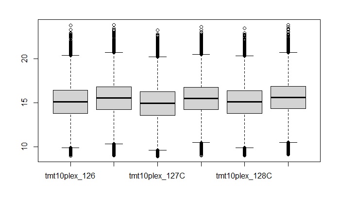

```r
##########################################################################################
psmQuant$sampleSignal = rowSums(psmQuant[,c(9:14)])
psmQuantFiltered = psmQuant %>%
  filter(grepl('heavy', label)) %>%
  filter(sampleSignal >= 60) %>%
  filter(!is.na(gene)) %>%
  filter(!grepl('-', gene))
boxplot(log2(psmQuantFiltered[,c(9:14)]))
```

We will also normalize the data to deal with any gross loading differences. We save both the non-normalized data here as well and check the normalization with a plot.

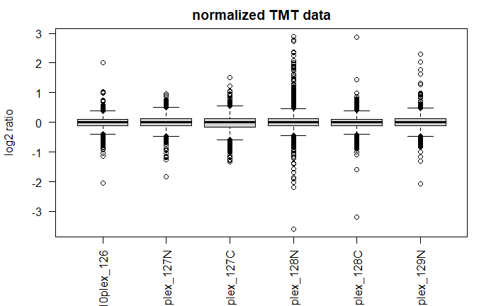

```r
##########################################################################################
quantInput = psmQuantFiltered[,c(1:7,9:14)]
saveRDS(quantInput, paste(baseRepository, '/proteomics20201119_SonyaTranslationSet3Tmd/dataset_peptideQuantDataPreDEqMS.rds', sep = ''))
quantInputLog = quantInput[,c(7,4,8:13)]
quantInputLog[,3:8][quantInputLog[,3:8] == 0] = NA
quantInputLog[,3:8] = log2(quantInputLog[,3:8])
quantInputNormalized = medianSweeping(quantInputLog, group_col = 2)
boxplot(quantInputNormalized, las = 2, ylab = 'log2 ratio', main = 'normalized TMT data')
```

All of the data look tight. Good. Lets continue with the DEqMS analysis. We need to build our sample table.

```r
##########################################################################################
cond = as.factor(c('dmso','isrib','dmso','isrib','dmso','isrib'))
design = model.matrix(~0+cond)
colnames(design) = gsub('cond', '', colnames(design))
```

Now we can build the Limma model.

```r
##########################################################################################
geneMatrix = as.matrix(quantInputNormalized)
limmaFit1 = lmFit(geneMatrix, design)
limmaContrasts = c('isrib - dmso')
limmaContrastDesign =  makeContrasts(contrasts = limmaContrasts, levels = design)
limmaFit2 = eBayes(contrasts.fit(limmaFit1, contrasts = limmaContrastDesign))
```

```r
##########################################################################################
psmCountTable = as.data.frame(table(quantInput$gene))
rownames(psmCountTable) = psmCountTable$Var1
limmaFit2$count = psmCountTable[rownames(limmaFit2$coefficients),2]
limmaFit3 = spectraCounteBayes(limmaFit2)
head(limmaFit3$coefficients)
```

```
       Contrasts
        isrib - dmso
  AAAS     0.1948289
  AACS     0.3688171
  AAGAB   -0.1331379
  AAMDC   -0.1564703
  AAMP    -0.1961913
  AAR2     0.4393871
```

```r
##
deqmsResults = outputResult(limmaFit3, coef_col = 1)
dim(deqmsResults)
```

```
[1] 4848   11
```

```r
write.table(deqmsResults,
            paste(baseRepository, '/proteomics20201119_SonyaTranslationSet3Tmd/dataset_deqms_24h_isrib-dmso.csv', sep = ''),
            sep = ',', row.names = FALSE, quote = FALSE)
```

Generate the variance plot to see the DEqMS model for the data.

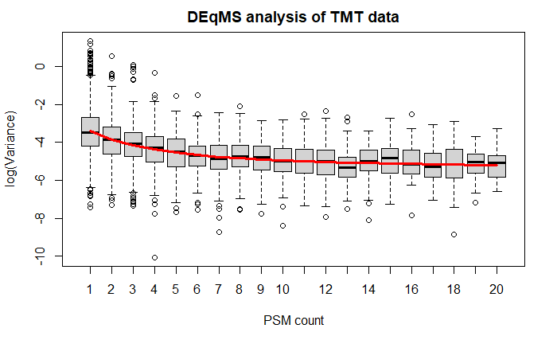

```r
##########################################################################################
VarianceBoxplot(limmaFit3, n=20, xlab = 'PSM count', main = 'DEqMS analysis of TMT data')
```

This looks as it should. Now let us make a volcano plot to show the data.

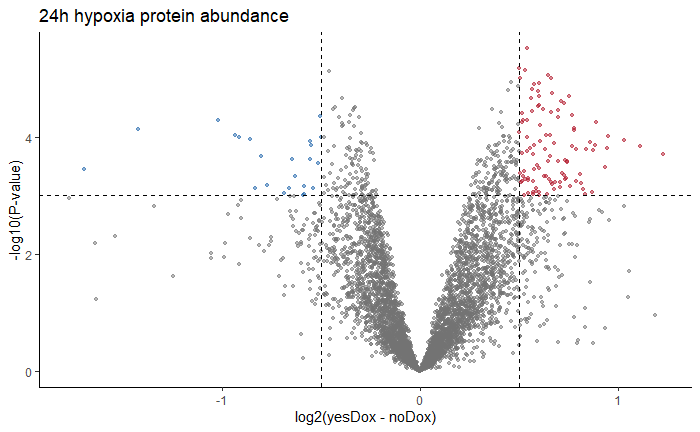

```r
##########################################################################################
deqmsResults = outputResult(limmaFit3, coef_col = 1)
deqmsResults$plotPValue = -log10(deqmsResults$sca.P.Value)
deqmsResults$pColors = ifelse(deqmsResults$logFC <= -0.5 & deqmsResults$plotPValue >= 3, brewer.pal(8,'RdBu')[8],
                              ifelse(deqmsResults$logFC >= 0.5 & deqmsResults$plotPValue >= 3, brewer.pal(8,'RdBu')[1],
                                     brewer.pal(8,'Greys')[6]))
#deqmsResults$pText = ifelse(grepl('IL1RAP$',deqmsResults$gene), deqmsResults$gene, '')
##
ggplot(deqmsResults, aes(logFC, plotPValue)) +
  geom_point(size = 1, color = deqmsResults$pColors, alpha = 0.5) +
  #geom_text_repel(label = deqmsResults$pText, nudge_x = -2) +
  labs(x = 'log2(yesDox - noDox)', y = '-log10(P-value)', title = '24h hypoxia protein abundance') +
  #scale_y_continuous(limits = c(0,12), breaks = seq(0,18,3)) +
  #scale_x_continuous(limits = c(-6,6), breaks = seq(-6,6,2)) +
  geom_vline(xintercept = c(-0.5,0.5), linetype = 'dashed') +
  geom_hline(yintercept = 3, linetype = 'dashed') +
  theme_classic()
ggsave(paste(baseRepository, '/proteomics20201119_SonyaTranslationSet3Tmd/scatter_deqms_24h_isrib-dmso.pdf', sep = ''),
       height = 4, width = 4, useDingbats = FALSE)
```

Try with a more simplistic approach.

[figure not shown]

```r
##########################################################################################
psmQuantData = as.data.frame(log2(apply(psmQuantFiltered[,c(9:14)], 2, function(x) x / psmQuantFiltered$tmt10plex_131C)))
psmQuantData$accession = psmQuantFiltered$accession
proQuantData = psmQuantData %>%
  group_by(accession) %>%
  summarise(across(tmt10plex_126:tmt10plex_129N, list(median = median)))

fit = lmFit(proQuantData[,2:7], design)
```

```
Partial NA coefficients for 8 probe(s)
```

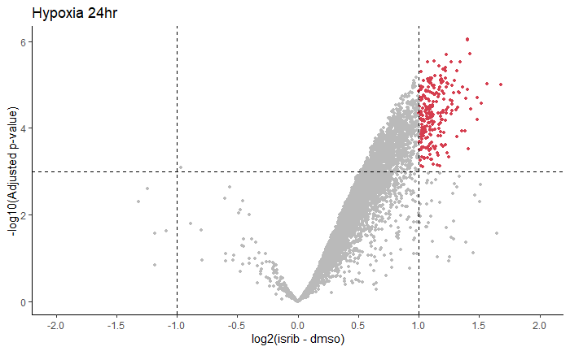

```r
limmaContrasts = c('isrib-dmso')
limmaContrastDesign =  makeContrasts(contrasts = limmaContrasts, levels = design)
fit2 = eBayes(contrasts.fit(fit, contrasts = limmaContrastDesign))
proQuantData$logFC = fit2$coefficients
proQuantData$pVal = fit2$p.value

##
proQuantData$pColors = ifelse(proQuantData$pVal < 0.001 & proQuantData$logFC > 1, brewer.pal(8,'Spectral')[1], brewer.pal(11,'RdGy')[8])
ggplot(proQuantData, aes(logFC, -log10(pVal))) +
  geom_point(size = 1, color = proQuantData$pColors) +
  labs(x = 'log2(isrib - dmso)', y = '-log10(Adjusted p-value)', title = 'Hypoxia 24hr') +
  geom_vline(xintercept = c(-1,1), linetype = 'dashed') +
  geom_hline(yintercept = -log10(0.001), linetype = 'dashed') +
  scale_x_continuous(limits = c(-2,2), breaks = seq(-2,2,0.5)) +
  theme_classic()
ggsave(paste(baseRepository, '/proteomics20201119_SonyaTranslationSet3Tmd/scatter_limmaComparison_isrib-dmso.pdf', sep = ''),
       height = 4, width = 4, useDingbats = FALSE)
```

```r
##
annotatedProtein = proQuantData %>%
  left_join(proteinAnnotation)
write.table(annotatedProtein, paste(baseRepository, '/proteomics20201119_SonyaTranslationSet3Tmd/dataset_limmaComparison_isrib-dmso.tsv', sep = ''),
            quote = FALSE, col.names = TRUE, row.names = FALSE, sep = '\t')
```

## Session info

```r
##########################################################################################
sessionInfo()
```

[output not shown]